# Predicting Global Trade Patterns

**Team Members:** Divya Vemula

Rahul Chauhan

Mani Krishna Tippani

2024-12-11

# Introduction

The project investigates the factors influencing which countries import the most commodities. With globalization, understanding export-import dynamics is crucial for optimizing trade strategies and supporting economic policies. Analyzing import patterns can provide insights into market dependencies, identify potential new markets, and enhance decision-making for exporters.

## Dataset Description

Data collect data using the U.S. Census Bureau’s International Trade API, which provides detailed information on exports and imports, including commodity codes and values. This will serve as our primary data source.

- **Dataset Source**: U.S. Census Bureau’s International Trade API
- **Dataset URL**: “https://api.census.gov/data/timeseries/intltrade/exports/hs”

*Variables Included*

**Total 41 Variables**

- **Export District Code**: Unique identifier for the export district.
- **District Name**: Name of the export district (e.g., Baltimore, MD).
- **Export Commodity Code**: Code representing the specific commodity being exported.
- **Export Commodity Long Description**: Detailed description of the commodity.
- **Export Commodity Short Description**: Brief description of the commodity.
- **Monthly Export Value (Total)**: Total value of exports for the month.
- **Total Monthly Export Value**: Cumulative total export value for the month.
- **Year-to-Date Export Value (Total)**: Cumulative value of exports for the year up to the specified month.
- **Total Year-to-Date Export Value**: Overall cumulative export value for the year.
- **Monthly Vessel Export Value**: Value of exports transported by vessel for the month.
- **Year-to-Date Vessel Export Value**: Cumulative value of vessel exports for the year.
- **Monthly Vessel Weight**: Weight of exports transported by vessel for the month.
- **Year-to-Date Vessel Weight**: Cumulative weight of vessel exports for the year.
- **Monthly Air Export Value**: Value of exports transported by air for the month.
- **Year-to-Date Air Export Value**: Cumulative value of air exports for the year.
- **Monthly Air Weight**: Weight of exports transported by air for the month.
- **Year-to-Date Air Weight**: Cumulative weight of air exports for the year.
- **Monthly Card Count**: Count of export transactions for the month.
- **Year-to-Date Card Count**: Count of export transactions for the year.
- **Monthly Quantity Value**: Value of exported quantities for the month.
- **Year-to-Date Quantity Value**: Cumulative value of exported quantities for the year.
- **Monthly Quantity Weight**: Weight of exported quantities for the month.
- **Year-to-Date Quantity Weight**: Cumulative weight of exported quantities for the year.
- **Commodity Level**: Level of detail for the commodity classification.
- **Country Code**: Code representing the country of destination.
- **Country Name**: Name of the destination country.
- **Domestic/Foreign Code**: Indicator of whether the data is for domestic or foreign entities.
- **Last Update Date**: Date when the data was last updated.
- **Month**: The month of observation.
- **Monthly Quantity 1**: Quantity metric for the month.
- **Quantity 1 Flag**: Flag indicating the status of Quantity 1.
- **Year-to-Date Quantity 1**: Cumulative quantity metric for the year.
- **Quantity 1 Year Flag**: Flag indicating the status of Year-to-Date Quantity 1.
- **Monthly Quantity 2**: Second quantity metric for the month.
- **Quantity 2 Flag**: Flag indicating the status of Quantity 2.
- **Year-to-Date Quantity 2**: Cumulative second quantity metric for the year.
- **Quantity 2 Year Flag**: Flag indicating the status of Year-to-Date Quantity 2.
- **Summary Level**: Level of summarization for the data.
- **Summary Level 2**: Additional level of summarization.
- **Unit Quantity 1**: Measurement unit for Quantity 1.
- **Unit Quantity 2**: Measurement unit for Quantity 2.

# Project Investigation

- In this project, we aim to analyze export data from the Baltimore, MD district to uncover insights related to export patterns, trends, and factors influencing export values. Using a dataset that includes various metrics, such as monthly and year-to-date export values, shipping methods, and commodity descriptions.
- This dataset enables to predict export values, for different commodities, transport modes across different countries.

## Why is this data interesting?

- Dataset holds both time-series and categorical features, provide an opportunity to explore patterns over time and the potential effects of commodity type, country of origin, and mode of transport on export volumes.
- Export data holds both short-term and long-term patterns that vary by mode, which RNNs are well-suited to capture due to their ability to maintain and use memory over sequences.
- Performance of different modes under varying conditions is essential for logistics optimization helps forecast inventory needs, plan shipments and reduce supply chain bottlenecks.

# Data Analysis Framework

**Data Exploration(EDA)**:

- Summary Statistics: Generate descriptive statistics to capture the essence of the data.
- Visualizations: Create plots to visualize trends over time and identify any seasonal patterns in exports.

## Load Required Libraries

```r
options(repos = c(CRAN = "https://cloud.r-project.org"))
if (!require('tidyverse')) install.packages('tidyverse'); library('tidyverse')
if (!require('h2o')) install.packages('h2o'); library('h2o')
if (!require('kableExtra')) install.packages('kableExtra'); library('kableExtra')
if (!require('DALEXtra')) install.packages('DALEXtra'); library('DALEXtra')
if (!require('skimr')) install.packages('skimr'); library('skimr')
if (!require('recipes')) install.packages('recipes'); library('recipes')
if (!require('janitor')) install.packages('janitor'); library('janitor')
if (!require('caret')) install.packages('caret'); library('caret')
if (!require('stringr')) install.packages('stringr'); library('stringr')
if (!require('DALEX')) install.packages('DALEX'); library('DALEX')
if (!require('ggplot2')) install.packages('ggplot2'); library('ggplot2')
if (!require('httr')) install.packages('httr'); library('httr')
if (!require('jsonlite')) install.packages('jsonlite'); library('jsonlite')
if (!require('tibble')) install.packages('tibble'); library('tibble')
if (!require('dplyr')) install.packages('dplyr'); library('dplyr')
if (!require('tidyr')) install.packages('tidyr'); library('tidyr')
```

## Data Modelling

**Read the PostProcessed data**

```r
api_url <- "https://api.census.gov/data/timeseries/intltrade/exports/hs?get=DISTRICT,DIST_NAME,E_COMMODITY,E_COMMODITY_LDESC,ALL_VAL_MO,ALL_VAL_YR,VES_VAL_MO,VES_VAL_YR,AIR_VAL_MO,AIR_VAL_YR,CC_YR,QTY_1_YR,QTY_2_YR,CTY_CODE,CTY_NAME,COMM_LVL,DF,LAST_UPDATE,YEAR,MONTH,VES_WGT_YR&YEAR=2013&MONTH=12&DISTRICT=13"
response <- GET(api_url, timeout(60))

if (status_code(response) == 200) {
  data <- fromJSON(content(response, "text"))
  headers <- data[1, ]
  records <- data[-1, ]

  # Convert to tibble and assign meaningful headers
  meaningful_headers <- c(
    "District Code", "District Name", "Export Commodity Code",
    "Export Commodity Long Description", "Total Monthly Export Value",
    "Total Year-to-Date Export Value", "Monthly Vessel Export Value",
    "Year-to-Date Vessel Export Value", "Monthly Air Export Value",
    "Year-to-Date Air Export Value", "Year-to-Date Card Count",
    "Quantity 1 Year-to-Date", "Quantity 2 Year-to-Date",
    "Country Code", "Country Name", "Commodity Level",
    "Domestic/Foreign Indicator", "Last Update", "Year",
    "Month", "Year-to-Date Vessel Weight"
  )
  data_table <- as_tibble(records, .name_repair = "unique")
  colnames(data_table) <- meaningful_headers
  print("Data successfully collected and loaded!")
} else {
  stop(paste("Error:", status_code(response)))
}
```

```
## [1] "Data successfully collected and loaded!"
```

```r
# Clean column names to ensure they are valid
data_table <- data_table %>% clean_names()

# Limit the data to 20,000 records
if (nrow(data_table) > 20000) {
  data_table <- data_table %>% sample_n(20000)  # Randomly sample 20,000 records
}

# Print the total number of records
total_records <- nrow(data_table)
print(paste("Total number of records:", total_records))
```

```
## [1] "Total number of records: 20000"
```

```r
# Step 2: Data Wrangling
# Check for missing values
missing_values <- sapply(data_table, function(x) sum(is.na(x)))
print(missing_values)
```

```
##                     district_code                     district_name
##                                 0                                 0
##             export_commodity_code export_commodity_long_description
##                                 0                                 0
##        total_monthly_export_value   total_year_to_date_export_value
##                                 0                                 0
##       monthly_vessel_export_value  year_to_date_vessel_export_value
##                                 0                                 0
##          monthly_air_export_value     year_to_date_air_export_value
##                                 0                                 0
##           year_to_date_card_count           quantity_1_year_to_date
##                                 0                                 0
##           quantity_2_year_to_date                      country_code
##                                 0                                 0
##                      country_name                   commodity_level
##                                 0                                 0
##        domestic_foreign_indicator                       last_update
##                                 0                                 0
##                              year                             month
##                                 0                                 0
##        year_to_date_vessel_weight                                na
##                                 0                                 0
##                              na_2                              na_3
##                                 0                                 0
```

```r
# Drop rows with missing data
data_table <- data_table %>% drop_na()

# Convert categorical variables to factors
data_table <- data_table %>%
  mutate(across(where(is.character), as.factor))

# Normalize numeric variables
numeric_cols <- data_table %>%
  select(where(is.numeric)) %>%
  colnames()
data_table <- data_table %>%
  mutate(across(all_of(numeric_cols), ~ (.-min(.))/(max(.)-min(.))))

# Filter columns to meet 20 predictors requirement
selected_columns <- c(
  "district_code", "district_name", "export_commodity_code",
  "export_commodity_long_description", "total_monthly_export_value",
  "total_year_to_date_export_value", "monthly_vessel_export_value",
  "year_to_date_vessel_export_value", "monthly_air_export_value",
  "year_to_date_air_export_value", "year_to_date_card_count",
  "quantity_1_year_to_date", "quantity_2_year_to_date",
  "country_code", "country_name", "commodity_level",
  "domestic_foreign_indicator", "last_update", "year",
  "month", "year_to_date_vessel_weight"
)
data_table <- data_table %>% select(all_of(selected_columns))
```

### Predictors Data

```r
# List of predictors to convert to factors
predictors <- c("district_code", "export_commodity_code", "export_commodity_long_description",
                "total_year_to_date_export_value", "monthly_vessel_export_value",
                "year_to_date_vessel_export_value", "monthly_air_export_value",
                "year_to_date_air_export_value", "year_to_date_card_count",
                "quantity_1_year_to_date", "quantity_2_year_to_date",
                "country_code", "country_name", "commodity_level",
                "domestic_foreign_indicator", "year_to_date_vessel_weight")

# Convert predictors to factors in the source dataframe
for (predictor in predictors) {
  data_table[[predictor]] <- as.factor(data_table[[predictor]])
}

# Verify the column types in the source dataframe
str(data_table)
```

```
## tibble [20,000 × 21] (S3: tbl_df/tbl/data.frame)
##  $ district_code                    : Factor w/ 1 level "13": 1 1 1 1 1 1 1 1 1 1 ...
##  $ district_name                    : Factor w/ 1 level "BALTIMORE, MD": 1 1 1 1 1 1 1 1 1 1 ...
##  $ export_commodity_code            : Factor w/ 5898 levels "-","01","010121",..: 5768 679 3659 1629 5675 3819 3734 4780 3713 1099 ...
##  $ export_commodity_long_description: Factor w/ 5390 levels "ABRASIVE ARTICLES ON A BASE OF WOVEN TEXTILE FABRIC ONLY",..: 4925 3657 2115 584 535 398 2722 4740 2539 3950 ...
##  $ total_monthly_export_value       : Factor w/ 3494 levels "0","10000","100000",..: 1 2664 1 1393 1 1 1 1 2324 3488 ...
##  $ total_year_to_date_export_value  : Factor w/ 13658 levels "10000","100000",..: 972 11740 4434 2579 2691 9835 4903 11166 13560 13623 ...
##  $ monthly_vessel_export_value      : Factor w/ 3206 levels "0","10000","100000",..: 1 2441 1 1292 1 1 1 1 1 3201 ...
##  $ year_to_date_vessel_export_value : Factor w/ 12552 levels "0","10000","100000",..: 903 10805 4105 2386 2492 9052 4542 10276 8946 12520 ...
##  $ monthly_air_export_value         : Factor w/ 348 levels "0","10000","10001",..: 1 1 1 1 1 1 1 1 238 1 ...
##  $ year_to_date_air_export_value    : Factor w/ 1837 levels "0","10000","100130",..: 1 1 1 1 1 1 1 1 1212 1 ...
##  $ year_to_date_card_count          : Factor w/ 530 levels "1","10","100",..: 44 313 167 375 412 1 167 335 335 167 ...
##  $ quantity_1_year_to_date          : Factor w/ 3035 levels "0","1","10","100",..: 1 1322 1 1 1 2 1 1 1061 1 ...
##  $ quantity_2_year_to_date          : Factor w/ 206 levels "0","1","100",..: 1 1 1 1 1 1 1 1 1 1 ...
##  $ country_code                     : Factor w/ 200 levels "-","0001","0003",..: 4 103 60 12 103 103 51 39 9 4 ...
##  $ country_name                     : Factor w/ 200 levels "AFGHANISTAN",..: 144 67 133 6 67 67 7 41 131 144 ...
##  $ commodity_level                  : Factor w/ 5 levels "-","HS10","HS2",..: 2 2 2 4 4 2 5 5 2 5 ...
##  $ domestic_foreign_indicator       : Factor w/ 3 levels "-","1","2": 2 2 1 2 1 2 1 2 2 1 ...
##  $ last_update                      : Factor w/ 1 level "0": 1 1 1 1 1 1 1 1 1 1 ...
##  $ year                             : Factor w/ 1 level "2013": 1 1 1 1 1 1 1 1 1 1 ...
##  $ month                            : Factor w/ 1 level "12": 1 1 1 1 1 1 1 1 1 1 ...
##  $ year_to_date_vessel_weight       : Factor w/ 10855 levels "0","1","10","100",..: 4218 5023 8777 7978 939 10201 390 6164 3002 989 ...
```

```r
train_x_tbl <- data_table |> select(-total_monthly_export_value)
train_x_tbl_sorted <- train_x_tbl |>
  arrange(desc(monthly_vessel_export_value))



kable(head(train_x_tbl_sorted, 10), format = "html", align = "l", caption = "Top 10 Rows of Training Predictor Variables") %>%
  kable_styling(full_width = TRUE, bootstrap_options = c("striped", "hover", "condensed", "responsive", "bordered"), position = "center", font_size = 14) %>%
  column_spec(1, bold = TRUE, background = "#D3D3D3") %>%
  row_spec(0, bold = TRUE, color = "white", background = "#4CAF50") %>%

  footnote(general = "Top 10 rows", general_title = "Note: ", footnote_as_chunk = TRUE)
```

Top 10 Rows of Training Predictor Variables

district_code

district_name

export_commodity_code

export_commodity_long_description

total_year_to_date_export_value

monthly_vessel_export_value

year_to_date_vessel_export_value

monthly_air_export_value

year_to_date_air_export_value

year_to_date_card_count

quantity_1_year_to_date

quantity_2_year_to_date

country_code

country_name

commodity_level

domestic_foreign_indicator

last_update

year

month

year_to_date_vessel_weight

13

BALTIMORE, MD

8529904720

RADAR APPARATUS PARTS

2364716

997803

1302370

52198

1062346

31

0

0

0003

EUROPEAN UNION

HS10

0

2013

12

4085

13

BALTIMORE, MD

8529904720

RADAR APPARATUS PARTS

1289944

997803

1289944

0

0

11

0

0

4239

LUXEMBOURG

HS10

1

0

2013

12

4083

13

BALTIMORE, MD

340219

ORGANIC SURFACE-ACTIVE AGENTS, WHETHER OR NOT PUT UP FOR RETAIL SALE, NESOI

1738065

9975

1738065

0

0

38

0

0

3XXX

SOUTH AMERICA

HS6

0

2013

12

183189

13

BALTIMORE, MD

340219

ORGANIC SURFACE-ACTIVE AGENTS, WHETHER OR NOT PUT UP FOR RETAIL SALE, NESOI

112049

9975

112049

0

0

6

0

0

3010

COLOMBIA

HS6

0

2013

12

38587

13

BALTIMORE, MD

3402195000

ORGANIC SURFACE ACTIVE AGENTS,OTHER,NOT AROMATIC OR MODIFIED AROMATIC

1716265

9975

1716265

0

0

37

173441

0

0024

LAFTA

HS10

0

2013

12

182139

13

BALTIMORE, MD

8708998175

PARTS AND ACCESSORIES, FOR MOTOR VEHICLES OF HEADINGS 8701 TO 8705, NESOI

554068

99524

530633

3219

23435

42

0

0

0014

PACIFIC RIM COUNTRIES

HS10

1

0

2013

12

238481

13

BALTIMORE, MD

470710

WASTE AND SCRAP OF UNBLEACHED KRAFT PAPER OR PAPERBOARD OR OF CORRUGATED PAPER OR PAPERBOARD

2386016

99489

2386016

0

0

70

0

0

3370

CHILE

HS6

0

2013

12

6084953

13

BALTIMORE, MD

4707100000

WASTE AND SCRAP OF UNBLEACHED KRAFT PAPER OR PAPERBOARD OR OF CORRUGATED PAPER OR PAPERBOARD

2386016

99489

2386016

0

0

70

6395

0

3370

CHILE

HS10

0

2013

12

6084953

13

BALTIMORE, MD

870333

PASSENGER MOTOR VEHICLES WITH COMPRESSION-IGNITION INTERNAL COMBUSTION PISTON ENGINE (DIESEL), CYLINDER CAPACITY OVER 2,500 CC

89218429

9942004

89218429

0

0

295

0

0

4XXX

EUROPE

HS6

2

0

2013

12

6939492

13

BALTIMORE, MD

320710

PREPARED PIGMENTS, PREPARED OPACIFIERS, PREPARED COLORS AND SIMILAR PREPARATIONS

99374

99374

99374

0

0

2

0

0

0014

PACIFIC RIM COUNTRIES

HS6

0

2013

12

12393

Note: Top 10 rows

### Outcome Varible Data

```r
train_y_tbl <- data_table |> select(total_monthly_export_value)
train_y_tbl_sorted <- train_y_tbl |>
  arrange(desc(total_monthly_export_value))


kable(head(train_y_tbl_sorted, 10), format = "html", align = "l", caption = "Top 10 Rows of Outcome Variable") %>%
  kable_styling(full_width = TRUE, bootstrap_options = c("striped", "hover", "condensed", "responsive", "bordered", "highlight"), position = "center", font_size = 14) %>%
  add_header_above(c("total_monthly_export_value Data" = 1)) %>%
  row_spec(0, bold = TRUE, color = "white", background = "#2C3E50") %>%
  column_spec(1, color = "white", background = "#E74C3C") %>%
  footnote(general = "This table displays the top 10 rows of the training target variable after preprocessing.", general_title = "Note: ", footnote_as_chunk = TRUE)
```

Top 10 Rows of Outcome Variable

| total_monthly_export_value Data total_monthly_export_value |
| --- |
| 99945 |
| 9982 |
| 9982 |
| 997803 |
| 9975 |
| 9975 |
| 9975 |
| 99489 |
| 99489 |
| 9942004 |

Note: This table displays the top 10 rows of the training target variable after preprocessing.

##initialize the h2o instance

```r
h2o.init(nthreads = -1)
```

```
##  Connection successful!
##
## R is connected to the H2O cluster:
##     H2O cluster uptime:         1 hours 50 minutes
##     H2O cluster timezone:       America/New_York
##     H2O data parsing timezone:  UTC
##     H2O cluster version:        3.44.0.3
##     H2O cluster version age:    11 months and 21 days
##     H2O cluster name:           H2O_started_from_R_divyavemula_jsk830
##     H2O cluster total nodes:    1
##     H2O cluster total memory:   0.40 GB
##     H2O cluster total cores:    8
##     H2O cluster allowed cores:  8
##     H2O cluster healthy:        TRUE
##     H2O Connection ip:          localhost
##     H2O Connection port:        54321
##     H2O Connection proxy:       NA
##     H2O Internal Security:      FALSE
##     R Version:                  R version 4.4.2 (2024-10-31)
```

# Load the saved H2o model

```r
h2o_model <- h2o.loadModel("TeamProject-Group1-PredictingGlobalTradePatterns.h2o")
summary(h2o_model)
```

```
## Model Details:
## ==============
##
## H2ORegressionModel: deeplearning
## Model Key:  TeamProject-Group1-PredictingGlobalTradePatterns
## Status of Neuron Layers: predicting total_monthly_export_value, regression, gaussian distribution, Quadratic loss, 7,413,377 weights/biases, 58.9 MB, 803,441 training samples, mini-batch size 1
##   layer units      type dropout       l1       l2 mean_rate rate_rms momentum
## 1     1 57657     Input  0.00 %       NA       NA        NA       NA       NA
## 2     2   128 Rectifier  0.00 % 0.000010 0.000010  0.003836 0.000000 0.216069
## 3     3   128 Rectifier  0.00 % 0.000010 0.000010  0.003836 0.000000 0.216069
## 4     4   128 Rectifier  0.00 % 0.000010 0.000010  0.003836 0.000000 0.216069
## 5     5     1    Linear      NA 0.000010 0.000010  0.003836 0.000000 0.216069
##   mean_weight weight_rms mean_bias bias_rms
## 1          NA         NA        NA       NA
## 2   -0.000182   0.013013 -7.912375 3.348563
## 3   -0.256982   0.083695 -1.604274 1.476976
## 4   -0.137196   0.163916  0.247930 0.572892
## 5    0.095969   0.255025 -0.621036 0.000000
##
## H2ORegressionMetrics: deeplearning
## ** Reported on training data. **
## ** Metrics reported on temporary training frame with 10041 samples **
##
## MSE:  0.0153426
## RMSE:  0.1238652
## MAE:  0.01012971
## RMSLE:  0.02582092
## Mean Residual Deviance :  0.0153426
##
##
## H2ORegressionMetrics: deeplearning
## ** Reported on validation data. **
## ** Metrics reported on full validation frame **
##
## MSE:  0.5036592
## RMSE:  0.7096895
## MAE:  0.253089
## RMSLE:  0.07578916
## Mean Residual Deviance :  0.5036592
##
```

[output cut: 34 more lines]

```
## ---
##                                     variable relative_importance
## 57652   monthly_air_export_value.missing(NA)            0.000000
## 57653    quantity_2_year_to_date.missing(NA)            0.000000
## 57654               country_name.missing(NA)            0.000000
## 57655               country_code.missing(NA)            0.000000
## 57656            commodity_level.missing(NA)            0.000000
## 57657 domestic_foreign_indicator.missing(NA)            0.000000
##       scaled_importance percentage
## 57652          0.000000   0.000000
## 57653          0.000000   0.000000
## 57654          0.000000   0.000000
## 57655          0.000000   0.000000
## 57656          0.000000   0.000000
## 57657          0.000000   0.000000
```

## Predictive performance of the model

**performance metrics**

```r
h2o_df <- as.h2o(data_table)
```

[output not shown]

```r
# Clean column names to ensure they are valid for H2O
colnames(h2o_df) <- gsub(" ", "_", colnames(h2o_df))  # Replace spaces with underscores
colnames(h2o_df) <- tolower(colnames(h2o_df))  # Convert to lowercase

# Check cleaned column names
print(colnames(h2o_df))
```

```
##  [1] "district_code"                     "district_name"
##  [3] "export_commodity_code"             "export_commodity_long_description"
##  [5] "total_monthly_export_value"        "total_year_to_date_export_value"
##  [7] "monthly_vessel_export_value"       "year_to_date_vessel_export_value"
##  [9] "monthly_air_export_value"          "year_to_date_air_export_value"
## [11] "year_to_date_card_count"           "quantity_1_year_to_date"
## [13] "quantity_2_year_to_date"           "country_code"
## [15] "country_name"                      "commodity_level"
## [17] "domestic_foreign_indicator"        "last_update"
## [19] "year"                              "month"
## [21] "year_to_date_vessel_weight"
```

```r
# **Ensure the target variable is numeric** before applying the log transformation
h2o_df$total_monthly_export_value <- as.numeric(h2o_df$total_monthly_export_value)

# Apply log transformation to reduce the impact of outliers
h2o_df$total_monthly_export_value <- log1p(h2o_df$total_monthly_export_value)

# Convert the target variable to numeric to ensure it is treated as regression
h2o_df$total_monthly_export_value <- as.numeric(h2o_df$total_monthly_export_value)

# Split the dataset into training and testing sets (80% train, 20% test)
splits <- h2o.splitFrame(data = h2o_df, ratios = 0.8, seed = 123)
train_h2o <- splits[[1]] # from training data
test_h2o <- splits[[2]] # from training data

performance <- h2o.performance(h2o_model, newdata = test_h2o)
print(performance)
```

```
## H2ORegressionMetrics: deeplearning
##
## MSE:  0.4504235
## RMSE:  0.671136
## MAE:  0.2340486
## RMSLE:  0.06440183
## Mean Residual Deviance :  0.4504235
```

### Plot: performance of the model

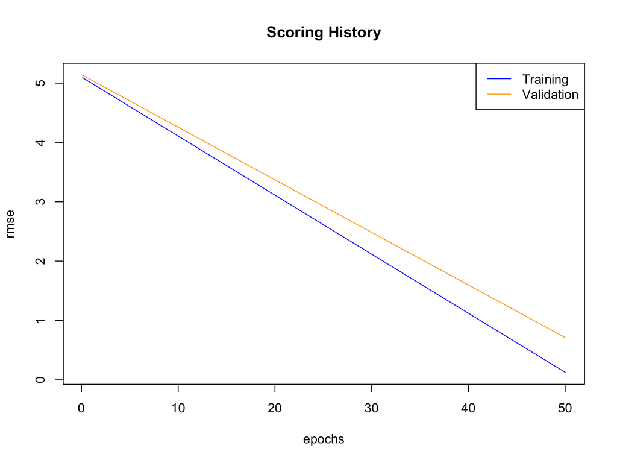

```r
plot(h2o_model)
```

## Plot Explanation**:

**Trend:** Both lines show a general decreasing trend in RMSE as the number of epochs increases. This indicates that the model’s performance improves with more epochs.

**Model Generalization:** - If the validation RMSE closely follows the training RMSE, it suggests that the model generalizes well to unseen data. - If there’s a significant divergence between the two lines, it could indicate overfitting (the model performs well on training data but poorly on validation data).

## Explain the model

**Explainer**

```r
test_data <- as.data.frame(test_h2o)

# Assuming your dataset is stored in 'test_data' (converted from the H2O object)
set.seed(123)  # For reproducibility
sampled_data <- test_data[sample(nrow(test_data), 1000), ]

# Use DALEX to explain the trained model
explainer <- DALEX::explain(h2o_model,
                            data = test_data[, predictors],
                            y = test_data$total_monthly_export_value,
                            label = "Deep Learning Model")
```

**New observation**

```r
# Extract a single row for prediction (assuming you want the first row)
new_observation <- test_h2o[1, ]

# Alternatively, extract a specific observation by row index
# new_observation <- test_h2o[specific_row_index, ]

# Make sure the factor levels match as needed
new_observation <- as.data.frame(new_observation)
new_observation <- new_observation %>%
  mutate(
    total_year_to_date_export_value = factor(total_year_to_date_export_value,
                                             levels = c("610000", "750000")),
    monthly_vessel_export_value = factor(monthly_vessel_export_value,
                                         levels = c("0", "200000")),
    year_to_date_vessel_export_value = factor(year_to_date_vessel_export_value,
                                              levels = c("610000", "720000")),
    monthly_air_export_value = factor(monthly_air_export_value,
                                      levels = c("0", "100000")),
    year_to_date_air_export_value = factor(year_to_date_air_export_value,
                                           levels = c("610000", "850000")),
    quantity_1_year_to_date = factor(quantity_1_year_to_date,
                                     levels = c("0")),
    quantity_2_year_to_date = factor(quantity_2_year_to_date,
                                     levels = c("0")),
    country_code = factor(country_code, levels = c("4XXX", "2XXX")),
    country_name = factor(country_name, levels = c("EUROPE", "CENTRAL AMERICA")),
    domestic_foreign_indicator = factor(domestic_foreign_indicator,
                                        levels = c("-", "1")),
    year_to_date_vessel_weight = factor(year_to_date_vessel_weight,
                                        levels = c("24551", "15000")),
    last_update = as.Date(Sys.Date())  # Add the 'last_update' column as the current date
  )

print(new_observation)
```

```
##   district_code district_name export_commodity_code
## 1            13 BALTIMORE, MD            8424890000
##                                                                                       export_commodity_long_description
## 1 MECHANICAL APPLIANCES (WHETHER OR NOT HAND OPERATED) FOR PROJECTING, DISPERSING OR SPRAYING LIQUIDS OR POWDERS, NESOI
##   total_monthly_export_value total_year_to_date_export_value
## 1                   10.75045                            <NA>
##   monthly_vessel_export_value year_to_date_vessel_export_value
## 1                           0                             <NA>
##   monthly_air_export_value year_to_date_air_export_value
## 1                     <NA>                          <NA>
##   year_to_date_card_count quantity_1_year_to_date quantity_2_year_to_date
## 1                       4                    <NA>                       0
##   country_code country_name commodity_level domestic_foreign_indicator
## 1         <NA>         <NA>            HS10                          1
##   last_update year month year_to_date_vessel_weight
## 1  2024-12-11 2013    12                       <NA>
```

```r
# Process the data
new_observation_tbl_skim = partition(skim(new_observation))
names(new_observation_tbl_skim)
```

```
## [1] "Date"    "factor"  "numeric"
```

```r
# Convert string columns to factors
string_2_factor_names_new_observation <- new_observation_tbl_skim$character$skim_variable
rec_obj_new_observation <- recipe(~ ., data = new_observation) |>
  step_string2factor(all_of(string_2_factor_names_new_observation)) |>
  prep()
new_observation_processed_tbl <- bake(rec_obj_new_observation, new_observation)

# Prediction-ready dataset
tradePatterns_prediction = new_observation_processed_tbl
```

## XAI-Method-1 - SHAP

[figure not shown]

```r
h2o_exp_shap <- predict_parts(
explainer = explainer, new_observation = tradePatterns_prediction, type = "shap", B = 3)
plot(h2o_exp_shap) + ggtitle("SHAP explanation")
```

### Key Insights of SHAP:

**Moderate Negative Impact:**

- Missing **country_code**.

**Negligible Impact:**

- Missing **total_year_to_date_export_value**.
- Missing **year_to_date_vessel_export_value**.
- Missing **year_to_date_vessel_weight**.

```r
h2o_exp_cp <- DALEX::predict_profile(
  explainer = explainer,        # The explainer object
  new_observation = as.data.frame(test_h2o[1, ])  # New observation for prediction
)
```

## XAI-Method-3 Model performance

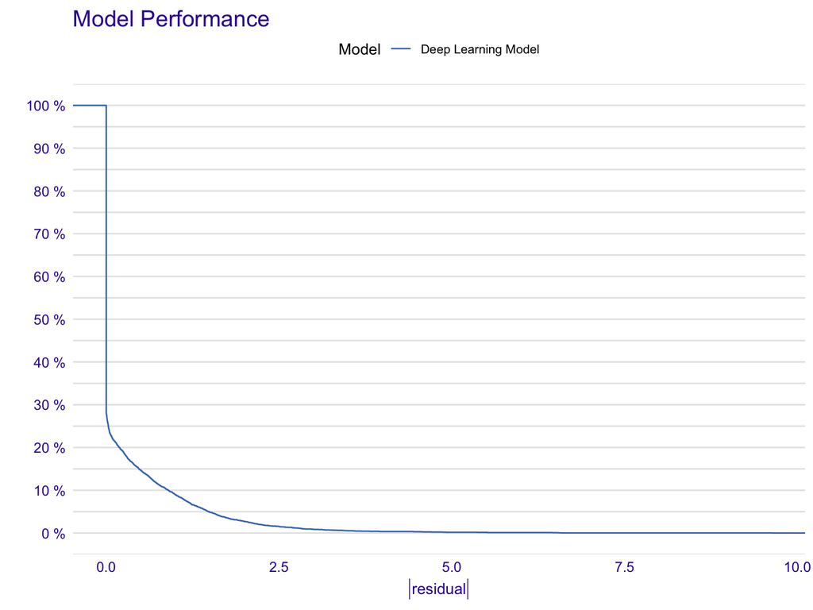

```r
# Model performance
mp_h2o <- model_performance(explainer)
plot(mp_h2o) + ggtitle("Model Performance")
```

## Conclusion

This project aims to provide valuable insights into global trade dynamics, supporting stakeholders in making informed decisions about export strategies and market targeting.